# Deconvolution of thymus bulk data identifying T-cell proportions.

Crhistian Cardona

30 September, 2020

**Computational Epigenomics Research group:** [epi-logos.com](https://epi-logos.com/)

# Context

We use the [SCDC library](https://meichendong.github.io/SCDC/articles/SCDC.html) based on [MuSiC](https://xuranw.github.io/MuSiC/articles/MuSiC.html) to conduct the bulk RNA-seq data deconvolution with a sc-RNA-seq reference thymic dataset described in [A cell atlas of human thymic development defines T cell repertoire formation](https://doi.org/10.1126/science.aay3224) composed of 12 time points (age), 29 cell types, and 36,084 single-nucleus transcriptomes. In the following markdown file, we are going to show how we use the deconvolution library to calculate the cell type proportions of each replica in a thymus bulk dataset and finally, we will run a multiple differential expression analysis over a bulk data simulated and the actual bulk dataset to find the possible list of genes that the method is missing for the tumor replicas.

Our paper: “Requeriment of DNMT1 to orchestrate epigenomic reprogramming during NPM-ALK driven T-cell lymphomagenesis” is published at [Life Science Alliance](https://doi.org/).

# Data configuration

First, we have to install 2 libraries that have been modified in order to use sparse matrices in R: Biobase and xbioc. Then we imported a modified version of the library [SCDC](https://meichendong.github.io/SCDC/articles/SCDC.html) that has been modified to support: sparse matrices, parallelism, and Dynamic threshold for markers selection, among other improvements. Finally, we imported the general libraries required to run the complete pipeline.

The generic functions have been saved in the scripting file: scripts/generic_functions.R"

```r
source("scripts/generic_functions.R", local = knitr::knit_global())
```

We used the scRNA-seq data from the publication: [A cell atlas of human thymic development defines T cell repertoire formation](https://doi.org/10.1126/science.aay3224); the data is located in [https://zenodo.org](https://zenodo.org/record/3711134#.Xwcsd5MzY0o). We have to download both the single cell and the bulk dataset, the last one located in the folder [data](https://github.com/crhisto/thymus_NPM-ALK_notebook/data/eset.thymus.bulk.sparse.RData.zip) in the repository.

```bash
cd data

#downloading the scRNA-seq dataset
wget https://zenodo.org/record/3711134/files/thymus_annotated_matrix_files.zip
unzip thymus_annotated_matrix_files.zip

#downloading the bulk RNA-seq dataset
#wget https://github.com/crhisto/thymus_NPM-ALK_notebook/data/eset.thymus.bulk.sparse.RData.zip
#unzip eset.thymus.bulk.sparse.RData.zip
```

Importing of the bulk data with the 12 samples in a ESET object type supporting sparse matrices.

```r
path.data <- paste0(getwd(), '/', 'data/')
load(paste0(path.data, "eset.thymus.bulk.sparse.RData"))
eset.thymus.bulk.sparse
```

```
## ExpressionSet (storageMode: lockedEnvironment)
## assayData: 50532 features, 12 samples
##   element names: exprs
## protocolData: none
## phenoData
##   sampleNames: Thy_ALKpos_KO_1 Thy_ALKpos_KO_2 ... Tumor_ALKpos_WT_3
##     (12 total)
##   varLabels: subjects
##   varMetadata: labelDescription
## featureData
##   featureNames: Gnai3 Pbsn ... Gm48308 (50532 total)
##   fvarLabels: fdata
##   fvarMetadata: labelDescription
## experimentData: use 'experimentData(object)'
## Annotation:
```

Importing data for the single cell dataset and creation of the corresponding seurat objects for both: the complete set of time points and the last 3 time points (‘4W’,‘8W’,‘24W’).

```r
path.data.sc <- paste0(path.data, "")

seurat_object.all <- ReadH5AD(paste0(path.data.sc, "HTA08.v02.A04.Science_mouse_total.h5ad"))
```

```
## Pulling expression matrices and metadata
```

```
## Data is unscaled
```

```
## Creating assay object
```

```
## Storing X as raw and raw as counts
```

```
## No variable feature expression found in h5ad file
```

```
## No dimensional reduction information found
```

```
## Assembling Seurat object
```

```
## No nearest-neighbor graph
```

```
## No additional layers found
```

```r
# I get all the columns for all tisue samples for all experiments.
annotations.all <- read.table(paste0(path.data.sc, "HTA08.v02.A04.Science_mouse_total.csv"),
                 header = TRUE,
                 sep = ",")

#I get the names of the cell types (clusters) to create the dataset
paste(shQuote(sort(unique(annotations.all$cell.types))), collapse=", ")
```

```
## [1] "'aDC', 'B', 'CD4+T', 'CD8+T', 'cTEC', 'DC1', 'DC2', 'DN(P)', 'DN(Q)', 'DP(P)', 'DP(Q)', 'Endo', 'Epi_unknown', 'Ery', 'Fb', 'HSC', 'IELpA', 'IELpB/NKT', 'Mac', 'Mono', 'mTEC', 'NK', 'NMP', 'pDC', 'TEC_early', 'Treg', 'VSMC', 'αβT(entry)', 'γδT'"
```

```r
paste(shQuote(sort(unique(annotations.all$age))), collapse=", ")
```

```
## [1] "'24W', '4W', '8W', 'E12', 'E13', 'E14', 'E15', 'E16', 'E17', 'E18', 'P0', 'Rag1KO'"
```

```r
cluster_list.thymus <- data.frame(cell.types = c('aDC', 'B', 'CD4+T', 'CD8+T', 'cTEC', 'DC1', 'DC2', 'DN(P)', 'DN(Q)', 'DP(P)', 'DP(Q)', 'Endo', 'Epi_unknown', 'Ery', 'Fb', 'HSC', 'IELpA', 'IELpB/NKT', 'Mac', 'Mono', 'mTEC', 'NK', 'NMP', 'pDC', 'TEC_early', 'Treg', 'VSMC', 'αβT(entry)', 'γδT'), cluster_normalized = paste0('cluster_', 1:29), cluster_order = as.numeric(c(1:29)))

#I add the cluster normalized for avoiding problems with names and special characters
annotations.all <- annotations.all %>% inner_join(cluster_list.thymus, by = "cell.types")

#I add the information from the annotations to the seurat object
seurat_object.all@meta.data$index_cell_id <- annotations.all$index
seurat_object.all@meta.data$cell_types_name <- annotations.all$cell.types
seurat_object.all@meta.data$stage <- annotations.all$stage
seurat_object.all@meta.data$age <- annotations.all$age
seurat_object.all@meta.data$sample_id <- annotations.all$sample_id
seurat_object.all@meta.data$cluster_normalized <- annotations.all$cluster_normalized

#Assign the identity
Idents(seurat_object.all) <- seurat_object.all$age

seurat_object.all <- subset(seurat_object.all, idents = c('E12', 'E13', 'E14', 'E15', 'E16', 'E17', 'E18', 'P0', '4W','8W','24W'))

#add filter of samples in the seurat object
seurat_object.4w_8w_24w <- subset(seurat_object.all, idents = c('4W','8W','24W'))

#create the count matrix base on the seurat object
counts.thymus.4w_8w_24w <- create_count_matrix(seurat_object.4w_8w_24w)
counts.thymus.all <- create_count_matrix(seurat_object.all)
```

## Deconvolution pipeline

Creation of object with the scRNA-seq data for the deconvolution

```r
#Use the function to create the sparse eset object
eset.sc.thymus.4.sparse <- create_sparse_eset_object(counts.thymus.4w_8w_24w, seurat_object.4w_8w_24w)
```

```
##    [[ suppressing 32 column names 'FCAImmP8084852-AAACCCACATAACGGG', 'FCAImmP8084852-AAACGAAAGCGGGTTA', 'FCAImmP8084852-AAACGAACAGACGCTC' ... ]]
##    [[ suppressing 32 column names 'FCAImmP8084852-AAACCCACATAACGGG', 'FCAImmP8084852-AAACGAAAGCGGGTTA', 'FCAImmP8084852-AAACGAACAGACGCTC' ... ]]
##    [[ suppressing 32 column names 'FCAImmP8084852-AAACCCACATAACGGG', 'FCAImmP8084852-AAACGAAAGCGGGTTA', 'FCAImmP8084852-AAACGAACAGACGCTC' ... ]]
```

```r
head(eset.sc.thymus.4.sparse)

eset.sc.thymus.4.sparse.all <- create_sparse_eset_object(counts.thymus.all, seurat_object.all)
```

```
##    [[ suppressing 32 column names 'FCAImmP8084852-AAACCCACATAACGGG', 'FCAImmP8084852-AAACGAAAGCGGGTTA', 'FCAImmP8084852-AAACGAACAGACGCTC' ... ]]
##    [[ suppressing 32 column names 'FCAImmP8084852-AAACCCACATAACGGG', 'FCAImmP8084852-AAACGAAAGCGGGTTA', 'FCAImmP8084852-AAACGAACAGACGCTC' ... ]]
##    [[ suppressing 32 column names 'FCAImmP8084852-AAACCCACATAACGGG', 'FCAImmP8084852-AAACGAAAGCGGGTTA', 'FCAImmP8084852-AAACGAACAGACGCTC' ... ]]
```

```r
head(eset.sc.thymus.4.sparse.all)
```

Creation of object for simulate bulk RNA-seq data from the scRNA-seq data.

```r
start_time <- Sys.time()
pseudo.eset.sc.thymus.4.sparse <- generateBulk_allcells(eset = eset.sc.thymus.4.sparse, ct.varname = "cluster_normalized", sample = "age", ct.sub = NULL)
end_time <- Sys.time()
end_time - start_time

start_time <- Sys.time()
pseudo.eset.sc.thymus.4.sparse.all <- generateBulk_allcells(eset.sc.thymus.4.sparse.all, ct.varname = "cluster_normalized", sample = "age", ct.sub = NULL)
```

```
##    [[ suppressing 11 column names '4W', '8W', '24W' ... ]]
##    [[ suppressing 11 column names '4W', '8W', '24W' ... ]]
##    [[ suppressing 11 column names '4W', '8W', '24W' ... ]]
```

```r
end_time <- Sys.time()
end_time - start_time
```

Using a hierarchical clustering, we can see with different parameters that in general there are 3 groups corresponding with the pseudotime shown in the paper [Park, J. et al. (21 Febrary 2020)](https://doi.org/10.1126/science.aay3224) Fig.2-G: Subcluster 1: DN (P), DN (Q): in this case, sometimes the two cell types appear in different clusters, however, we know that both are Double Negative cell types in different stages, hence, both are related. Subcluster 2: DP(P), DP(Q), αβT(entry) Subcluster 3: CD4+T, CD8+T Also, we use different clusters configurations, checking the final deviance and the Pearson Correlation.

```r
cluster_list_pseudotime.sub <- paste0('cluster_', c(8,9,10,11,28,4,3))

start_time <- Sys.time()

basic.object <- SCDC_basis(x = eset.sc.thymus.4.sparse,
                       ct.varname = "cluster_normalized",
                       sample = "age",
                       ct.sub = cluster_list_pseudotime.sub)
```

```
## Creating Basis Matrix adjusted for maximal variance weight
```

```r
#Time of execution
end_time <- Sys.time()
end_time - start_time
```

```
## Time difference of 49.01633 secs
```

```r
data.mvw <- basic.object$basis.mvw[, paste0('cluster_', c(8,9,10,11,28,4,3))]
list_pseudotime <- c('DN(P)', 'DN(Q)', 'DP(P)', 'DP(Q)', 'αβT(entry)', 'CD8+T', 'CD4+T')
colnames(data.mvw) <- list_pseudotime

#clustering for deconvolution
df.d <- dist(t(log(data.mvw + 1e-10)), method = "euclidean")
hclust_single <- hclust(df.d, method = "single")

cut_avg <- cutree(hclust_single, k =4)
cut_avg
```

```
##      DN(P)      DN(Q)      DP(P)      DP(Q) αβT(entry)      CD8+T      CD4+T
##          1          2          3          3          3          4          4
```

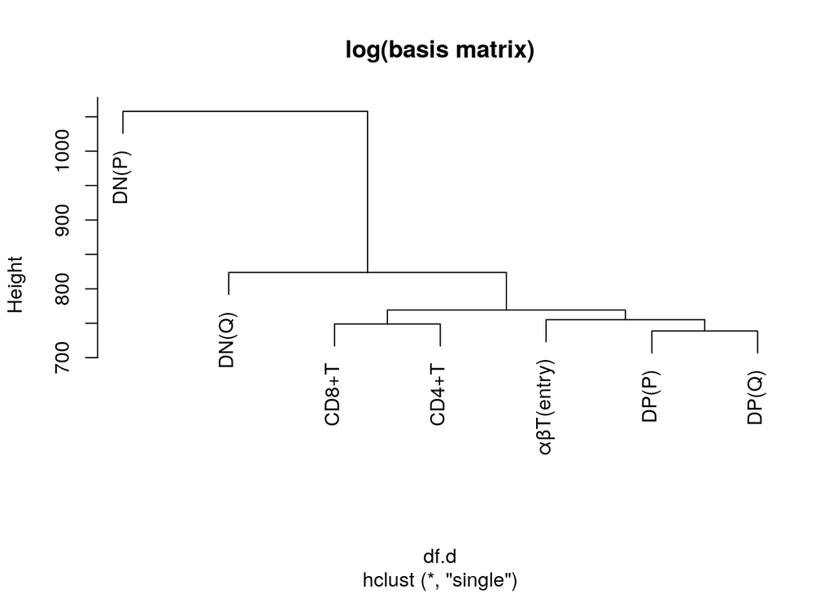

```r
plot(hclust_single, main = "log(basis matrix)")
```

### Deconvolution simulation

Execution of the deconvolution with the simulated bulk database on the single-cell dataset. Given the Boostraping sampling, there is variability across different runs, however with a high boostrap.number, specifically in this case with 40, both the number of marker genes, the Pearson correlation, and the deviance have low variation. Be aware of the configuration of the machine that you are using for executing the deconvolution. In this case for each thread, you may need a maximum of 3 GB in RAM.

```r
cluster_list_pseudotime.sub <- paste0('cluster_', c(8,9,10,11,28,4,3))
cluster_list_pseudotime.fl.sub <- c("Subcluster 1", "Subcluster 2", "Subcluster 3")

#add the metacluster information
eset.sc.thymus.4.sparse.metacluster <- add_metacluster_pseudotime(eset.sc.thymus.4.sparse)

start_time <- Sys.time()

#run the tree guided process with subclusters
deconvolution.simulation <- SCDC_prop_subcl_marker(bulk.eset = pseudo.eset.sc.thymus.4.sparse$pseudo_eset,
                                                   sc.eset = eset.sc.thymus.4.sparse.metacluster,
                                                   ct.varname = "cluster_normalized", fl.varname = "metacluster", sample = "age",
                                                   ct.sub = cluster_list_pseudotime.sub,ct.fl.sub = cluster_list_pseudotime.fl.sub,
                                                   truep = pseudo.eset.sc.thymus.4.sparse$truep, select.marker = TRUE,
                                                   parallelize = T, core_number = 7,
                                                   marker_gene_strategy = 'boostrap_outliers',
                                                   iteration.minimun_number_markers = 28, iteration.use_maximum = TRUE, iteration.maximo_genes = 35,
                                                   iteration.use_final_foldchange = TRUE,
                                                   weight.basis = F, bootstrap.number = 40, bootstrap.sample_size = 4)
```

```
## SCDC basis for main cluster...
```

```
## Creating Basis Matrix adjusted for maximal variance weight
```

```
## SCDC basis for secondary cluster (metacluster)...
```

```
## Creating Basis Matrix adjusted for maximal variance weight
```

```
## Marker gene strategy: boostrap_outliers
```

```
## [1] "Parameters for iteration: iteration.minimun_number_markers:28, iteration.use_maximum:TRUE iteration.maximo_genes:35"
## [1] "Executing parallelized function..."
## [1] "Number of cores to use: 7"
## [1] "Temporal folder: /mnt_volumen/GIT_REPOSITORIES/publication_thymus_NPM-ALK_notebook/thymus_NPM-ALK_notebook/temporal_log/"
## [1] "The temporal folder has been deleted."
## [1] "Cluster order: 'cluster_11', 'cluster_28', 'cluster_3', 'cluster_10', 'cluster_4', 'cluster_9', 'cluster_8'"
## [1] "Processing 7 log files."
## [1] "Recovering log file: cluster_10.log"
## [1] "Cluster: cluster_10 Number of cells: 3514"
## [1] "cluster_10(1332) -> Number of cells: 3514 *****Genes: 'Ube2c', 'Rrm2', 'Birc5', 'Top2a', 'Mki67', 'Nusap1', 'Cenpf', 'Ccna2', 'Ccnb2', 'Cdca8', 'Cdk1', 'Spc24', 'Cdca3', 'Tpx2', 'Ccnb1', 'Cdc20', 'Kif11', 'Pbk', 'Fbxo5', 'Spc25', 'Cenpe', 'Hmmr', 'Tuba1b', 'Cks2', 'Prc1', 'Tyms', 'Tacc3', 'A…
## [1] ""
## [1] "Final Genes (35):'Ube2c', 'Rrm2', 'Birc5', 'Top2a', 'Mki67', 'Nusap1', 'Cenpf', 'Ccna2', 'Ccnb2', 'Cdca8', 'Cdk1', 'Spc24', 'Cdca3', 'Tpx2', 'Ccnb1', 'Cdc20', 'Kif11', 'Pbk', 'Fbxo5', 'Spc25', 'Cenpe', 'Hmmr', 'Tuba1b', 'Cks2', 'Prc1', 'Tyms', 'Tacc3', 'Aurkb', 'Hmgb2', 'Racgap1', 'Esco2', '…
## [1] ""
## [1] ""
## [1] "Recovering log file: cluster_11.log"
```

[output cut: 48 more lines]

```
## Global minimun LFC (1 marker): 0
```

```
## Global minimun LFC (Minimum 20 genes marker): 0
```

```
## Selected 174 marker genes by Wilcoxon test...
```

```
## Genes:'Rag1', 'Slc7a11', 'Tctex1d1', 'Arl5c', 'Chrna9', 'Gtf2h4', 'Arpp21', 'Mier1', 'Dgkeos', 'Ets2', 'Cd4', 'Rmnd5a', 'Endou', 'Aqp11', 'Ssbp2', 'Cd8b1', 'Mxd4', 'Nebl', 'Rcsd1', 'Dnajc15', 'Themis', 'Tcf12', 'Xrcc6', 'Klf13', 'Trp53inp1', 'Nsg2', 'Dck', 'Socs1', 'Cyb5a', 'Dntt', 'Cd8a', 'Ldhb'…
```

```
## Used 174 common genes for all cell types,
##  Used 174 common genes for first level cell types...
```

```
## Genes that are not shared between SC and bulk:
```

```
## *Cluster(0):
```

```
## **Metacluster(0):
```

```
## Used 7 cell types in deconvolution...
##  Used 3 first level cell types ...
```

```
##
## 4W has common genes 174 ...
```

```
## WNNLS for First level clusters Converged at iteration 2
```

```
## ***First level clusters -> Step sum squared residuals (deviance) : 0.046524213522564
```

```
## WNNLS for Second level clusters: 'cluster_8', 'cluster_9' Converged at iteration 1
```

```
## ***Step sum squared residuals (deviance): 0.00760592378253757
```

```
## WNNLS for Second level clusters: 'cluster_10', 'cluster_11', 'cluster_28' Converged at iteration 1
```

```
## ***Step sum squared residuals (deviance): 0.0111987570316263
```

```
## WNNLS for Second level clusters: 'cluster_3', 'cluster_4' Converged at iteration 1
```

```
## ***Step sum squared residuals (deviance): 0.0079175632054388
```

```
## Sum of deviance (Squared residuals) for the sample: 0.0267222440196027
```

```
##
## 8W has common genes 174 ...
```

```
## WNNLS for First level clusters Converged at iteration 2
```

```
## ***First level clusters -> Step sum squared residuals (deviance) : 0.0494029947048418
```

```
## WNNLS for Second level clusters: 'cluster_8', 'cluster_9' Converged at iteration 1
```

```
## ***Step sum squared residuals (deviance): 0.00971049948875929
```

```
## WNNLS for Second level clusters: 'cluster_10', 'cluster_11', 'cluster_28' Converged at iteration 1
```

```
## ***Step sum squared residuals (deviance): 0.0113153511904056
```

```
## WNNLS for Second level clusters: 'cluster_3', 'cluster_4' Converged at iteration 1
```

```
## ***Step sum squared residuals (deviance): 0.00730101233410536
```

```
## Sum of deviance (Squared residuals) for the sample: 0.0283268630132702
```

```
##
## 24W has common genes 174 ...
```

```
## WNNLS for First level clusters Converged at iteration 2
```

```
## ***First level clusters -> Step sum squared residuals (deviance) : 0.0449514718420172
```

```
## WNNLS for Second level clusters: 'cluster_8', 'cluster_9' Converged at iteration 1
```

```
## ***Step sum squared residuals (deviance): 0.0104900460770455
```

```
## WNNLS for Second level clusters: 'cluster_10', 'cluster_11', 'cluster_28' Converged at iteration 1
```

```
## ***Step sum squared residuals (deviance): 0.0114600060271316
```

```
## WNNLS for Second level clusters: 'cluster_3', 'cluster_4' Converged at iteration 1
```

```
## ***Step sum squared residuals (deviance): 0.00731994272651891
```

```
## Sum of deviance (Squared residuals) for the sample: 0.029269994830696
```

```
##
## ***Global residuals fl (deviance) subclustering: 0.140878680069423
```

```
##
## ***Global residuals (deviance): 0.0843191018635689
```

```r
deconvolution.simulation$prop.est
```

```
##        cluster_8  cluster_9 cluster_10 cluster_11 cluster_28  cluster_3
## 4W  0.0007923757 0.02073864  0.1914932  0.4707908  0.1452946 0.11031054
## 8W  0.0012250863 0.03188624  0.1882338  0.4623273  0.1426727 0.11206850
## 24W 0.0014857362 0.03872218  0.1939739  0.4766675  0.1471802 0.09161386
##      cluster_4
## 4W  0.06057989
## 8W  0.06158633
## 24W 0.05035656
```

```r
deconvolution.simulation$peval$evals.table
```

```
##         RMSD     mAD      R
## SCDC 0.01618 0.01303 0.9971
```

```r
deconvolution.simulation$peval$pearson.sample.table
```

```
##          24W      4W     8W
## SCDC 0.99817 0.99802 0.9951
```

```r
#Time of execution: 60 min using 7 threads and approx. 17GB of RAM
end_time <- Sys.time()
end_time - start_time
```

```
## Time difference of 59.65857 mins
```

### Deconvolution of thymus bulk data

Execution of the deconvolution with the actual bulk thymus data, using the optimized parameters found in the simulation.

```r
#add the metacluster information
eset.sc.thymus.4.sparse.metacluster <- add_metacluster_pseudotime(eset.sc.thymus.4.sparse)

start_time <- Sys.time()

deconvolution.real_data <- SCDC_prop_subcl_marker(bulk.eset = eset.thymus.bulk.sparse, sc.eset = eset.sc.thymus.4.sparse.metacluster,
                                                  ct.varname = "cluster_normalized", fl.varname = "metacluster", sample = "age",
                                                  ct.sub = cluster_list_pseudotime.sub, ct.fl.sub = cluster_list_pseudotime.fl.sub,
                                                  select.marker = TRUE, parallelize = T, core_number = 7,
                                                  marker_gene_strategy = 'boostrap_outliers',
                                                  iteration.minimun_number_markers = 28, iteration.use_maximum = TRUE, iteration.maximo_genes = 35,
                                                  iteration.use_final_foldchange = TRUE,
                                                  weight.basis = F, bootstrap.number = 40, bootstrap.sample_size = 4)
```

```
## SCDC basis for main cluster...
```

```
## Creating Basis Matrix adjusted for maximal variance weight
```

```
## SCDC basis for secondary cluster (metacluster)...
```

```
## Creating Basis Matrix adjusted for maximal variance weight
```

```
## Marker gene strategy: boostrap_outliers
```

```
## [1] "Parameters for iteration: iteration.minimun_number_markers:28, iteration.use_maximum:TRUE iteration.maximo_genes:35"
## [1] "Executing parallelized function..."
## [1] "Number of cores to use: 7"
## [1] "Temporal folder: /mnt_volumen/GIT_REPOSITORIES/publication_thymus_NPM-ALK_notebook/thymus_NPM-ALK_notebook/temporal_log/"
## [1] "Cluster order: 'cluster_11', 'cluster_28', 'cluster_3', 'cluster_10', 'cluster_4', 'cluster_9', 'cluster_8'"
## [1] "Processing 7 log files."
## [1] "Recovering log file: cluster_10.log"
## [1] "Cluster: cluster_10 Number of cells: 3514"
## [1] "cluster_10(1332) -> Number of cells: 3514 *****Genes: 'Ube2c', 'Rrm2', 'Birc5', 'Top2a', 'Mki67', 'Nusap1', 'Cenpf', 'Ccna2', 'Ccnb2', 'Cdca8', 'Cdk1', 'Spc24', 'Cdca3', 'Tpx2', 'Ccnb1', 'Cdc20', 'Kif11', 'Pbk', 'Fbxo5', 'Spc25', 'Cenpe', 'Hmmr', 'Tuba1b', 'Cks2', 'Prc1', 'Tyms', 'Tacc3', 'A…
## [1] ""
## [1] "Final Genes (35):'Ube2c', 'Rrm2', 'Birc5', 'Top2a', 'Mki67', 'Nusap1', 'Cenpf', 'Ccna2', 'Ccnb2', 'Cdca8', 'Cdk1', 'Spc24', 'Cdca3', 'Tpx2', 'Ccnb1', 'Cdc20', 'Kif11', 'Pbk', 'Fbxo5', 'Spc25', 'Cenpe', 'Hmmr', 'Tuba1b', 'Cks2', 'Prc1', 'Tyms', 'Tacc3', 'Aurkb', 'Hmgb2', 'Racgap1', 'Esco2', '…
## [1] ""
## [1] ""
## [1] "Recovering log file: cluster_11.log"
## [1] "Cluster: cluster_11 Number of cells: 8651"
```

[output cut: 47 more lines]

```
## Global minimun LFC (1 marker): 0
```

```
## Global minimun LFC (Minimum 20 genes marker): 0
```

```
## Selected 183 marker genes by Wilcoxon test...
```

```
## Genes:'Rag1', 'Slc7a11', 'Tctex1d1', 'Arl5c', 'Chrna9', 'Gtf2h4', 'Arpp21', 'Mier1', 'Dgkeos', 'Ets2', 'Cd4', 'Rmnd5a', 'Endou', 'Aqp11', 'Ssbp2', 'Cd8b1', 'Mxd4', 'Nebl', 'Rcsd1', 'Dnajc15', 'Themis', 'Tcf12', 'Xrcc6', 'Klf13', 'Trp53inp1', 'Nsg2', 'Dck', 'Socs1', 'Cyb5a', 'Dntt', 'Cd8a', 'Ldhb'…
```

```
## Used 182 common genes for all cell types,
##  Used 182 common genes for first level cell types...
```

```
## Genes that are not shared between SC and bulk:
```

```
## *Cluster(1):'Rag1'
```

```
##     -->non_commongenes.basis(0):
```

```
##     -->non_commongenes.bulk(0):
```

```
##     -->non_commongenes.markers(0):
```

```
## **Metacluster(1):'Rag1'
```

```
## Used 7 cell types in deconvolution...
##  Used 3 first level cell types ...
```

```
##
## Thy_ALKpos_KO_1 has common genes 182 ...
```

```
## WNNLS for First level clusters Converged at iteration 236
```

```
## ***First level clusters -> Step sum squared residuals (deviance) : 0.844247355587683
```

```
## WNNLS for Second level clusters: 'cluster_8', 'cluster_9' Converged at iteration 1
```

```
## ***Step sum squared residuals (deviance): 0.0124999144993672
```

```
## WNNLS for Second level clusters: 'cluster_10', 'cluster_11', 'cluster_28' Converged at iteration 1
```

```
## ***Step sum squared residuals (deviance): 0.0199361500808176
```

```
## WNNLS for Second level clusters: 'cluster_3', 'cluster_4' Converged at iteration 1
```

```
## ***Step sum squared residuals (deviance): 0.00993142355207615
```

```
## Sum of deviance (Squared residuals) for the sample: 0.042367488132261
```

```
##
## Thy_ALKpos_KO_2 has common genes 182 ...
```

```
## WNNLS for First level clusters Converged at iteration 258
```

```
## ***First level clusters -> Step sum squared residuals (deviance) : 0.861016041949188
```

```
## WNNLS for Second level clusters: 'cluster_8', 'cluster_9' Converged at iteration 1
```

```
## ***Step sum squared residuals (deviance): 0.0115731465097425
```

```
## WNNLS for Second level clusters: 'cluster_10', 'cluster_11', 'cluster_28' Converged at iteration 1
```

```
## ***Step sum squared residuals (deviance): 0.0199039831628442
```

```
## WNNLS for Second level clusters: 'cluster_3', 'cluster_4' Converged at iteration 2
```

```
## ***Step sum squared residuals (deviance): 0.951393215651336
```

```
## Sum of deviance (Squared residuals) for the sample: 0.982870345323922
```

```
##
## Thy_ALKpos_KO_3 has common genes 182 ...
```

```
## WNNLS for First level clusters Converged at iteration 298
```

```
## ***First level clusters -> Step sum squared residuals (deviance) : 0.748671739644322
```

```
## WNNLS for Second level clusters: 'cluster_8', 'cluster_9' Converged at iteration 1
```

```
## ***Step sum squared residuals (deviance): 0.0128387472392003
```

```
## WNNLS for Second level clusters: 'cluster_10', 'cluster_11', 'cluster_28' Converged at iteration 1
```

```
## ***Step sum squared residuals (deviance): 0.0199104381139169
```

```
## WNNLS for Second level clusters: 'cluster_3', 'cluster_4' Converged at iteration 2
```

```
## ***Step sum squared residuals (deviance): 0.306498900505266
```

```
## Sum of deviance (Squared residuals) for the sample: 0.339248085858383
```

```
##
## Thy_KO_1 has common genes 180 ...
```

```
## WNNLS for First level clusters Converged at iteration 350
```

```
## ***First level clusters -> Step sum squared residuals (deviance) : 0.729498448983705
```

```
## WNNLS for Second level clusters: 'cluster_8', 'cluster_9' Converged at iteration 1
```

```
## ***Step sum squared residuals (deviance): 0.00813857219214179
```

```
## WNNLS for Second level clusters: 'cluster_10', 'cluster_11', 'cluster_28' Converged at iteration 1
```

```
## ***Step sum squared residuals (deviance): 0.0196972399533063
```

```
## WNNLS for Second level clusters: 'cluster_3', 'cluster_4' Converged at iteration 2
```

```
## ***Step sum squared residuals (deviance): 0.89386924403007
```

```
## Sum of deviance (Squared residuals) for the sample: 0.921705056175518
```

```
##
## Thy_KO_2 has common genes 181 ...
```

```
## WNNLS for First level clusters Converged at iteration 638
```

```
## ***First level clusters -> Step sum squared residuals (deviance) : 0.893719795012481
```

```
## WNNLS for Second level clusters: 'cluster_8', 'cluster_9' Converged at iteration 1
```

```
## ***Step sum squared residuals (deviance): 0.0123651089088833
```

```
## WNNLS for Second level clusters: 'cluster_10', 'cluster_11', 'cluster_28' Converged at iteration 1
```

```
## ***Step sum squared residuals (deviance): 0.0151768654594831
```

```
## WNNLS for Second level clusters: 'cluster_3', 'cluster_4' Converged at iteration 1
```

```
## ***Step sum squared residuals (deviance): 0.0225277770083059
```

```
## Sum of deviance (Squared residuals) for the sample: 0.0500697513766723
```

```
##
## Thy_KO_3 has common genes 181 ...
```

```
## WNNLS for First level clusters Converged at iteration 393
```

```
## ***First level clusters -> Step sum squared residuals (deviance) : 0.487609680930934
```

```
## WNNLS for Second level clusters: 'cluster_8', 'cluster_9' Converged at iteration 1
```

```
## ***Step sum squared residuals (deviance): 0.00832747587734177
```

```
## WNNLS for Second level clusters: 'cluster_10', 'cluster_11', 'cluster_28' Converged at iteration 1
```

```
## ***Step sum squared residuals (deviance): 0.0210719557944642
```

```
## WNNLS for Second level clusters: 'cluster_3', 'cluster_4' Converged at iteration 2
```

```
## ***Step sum squared residuals (deviance): 0.340622762406456
```

```
## Sum of deviance (Squared residuals) for the sample: 0.370022194078262
```

```
##
## Thy_WT_1 has common genes 182 ...
```

```
## WNNLS for First level clusters Converged at iteration 334
```

```
## ***First level clusters -> Step sum squared residuals (deviance) : 0.761365677921456
```

```
## WNNLS for Second level clusters: 'cluster_8', 'cluster_9' Converged at iteration 1
```

```
## ***Step sum squared residuals (deviance): 0.0086020395011458
```

```
## WNNLS for Second level clusters: 'cluster_10', 'cluster_11', 'cluster_28' Converged at iteration 1
```

```
## ***Step sum squared residuals (deviance): 0.0194325301167469
```

```
## WNNLS for Second level clusters: 'cluster_3', 'cluster_4' Converged at iteration 2
```

```
## ***Step sum squared residuals (deviance): 1.10042068559795
```

```
## Sum of deviance (Squared residuals) for the sample: 1.12845525521584
```

```
##
## Thy_WT_2 has common genes 182 ...
```

```
## WNNLS for First level clusters Converged at iteration 384
```

```
## ***First level clusters -> Step sum squared residuals (deviance) : 0.736080765879529
```

```
## WNNLS for Second level clusters: 'cluster_8', 'cluster_9' Converged at iteration 1
```

```
## ***Step sum squared residuals (deviance): 0.00687636462820053
```

```
## WNNLS for Second level clusters: 'cluster_10', 'cluster_11', 'cluster_28' Converged at iteration 1
```

```
## ***Step sum squared residuals (deviance): 0.0207335512883698
```

```
## WNNLS for Second level clusters: 'cluster_3', 'cluster_4' Converged at iteration 2
```

```
## ***Step sum squared residuals (deviance): 0.435782368232573
```

```
## Sum of deviance (Squared residuals) for the sample: 0.463392284149143
```

```
##
## Thy_WT_3 has common genes 182 ...
```

```
## WNNLS for First level clusters Converged at iteration 336
```

```
## ***First level clusters -> Step sum squared residuals (deviance) : 0.778049558439522
```

```
## WNNLS for Second level clusters: 'cluster_8', 'cluster_9' Converged at iteration 1
```

```
## ***Step sum squared residuals (deviance): 0.0096997403824673
```

```
## WNNLS for Second level clusters: 'cluster_10', 'cluster_11', 'cluster_28' Converged at iteration 1
```

```
## ***Step sum squared residuals (deviance): 0.0208341122581906
```

```
## WNNLS for Second level clusters: 'cluster_3', 'cluster_4' Converged at iteration 2
```

```
## ***Step sum squared residuals (deviance): 0.689759242554055
```

```
## Sum of deviance (Squared residuals) for the sample: 0.720293095194713
```

```
##
## Tumor_ALKpos_WT_1 has common genes 176 ...
```

```
## WNNLS for First level clusters Converged at iteration 946
```

```
## ***First level clusters -> Step sum squared residuals (deviance) : 0.980750758122681
```

```
## WNNLS for Second level clusters: 'cluster_8', 'cluster_9' Converged at iteration 1
```

```
## ***Step sum squared residuals (deviance): 0.0175162882377408
```

```
## WNNLS for Second level clusters: 'cluster_10', 'cluster_11', 'cluster_28' Converged at iteration 1
```

```
## ***Step sum squared residuals (deviance): 0.0284977465607605
```

```
## Sum of deviance (Squared residuals) for the sample: 0.0460140347985013
```

```
##
## Tumor_ALKpos_WT_2 has common genes 175 ...
```

```
## WNNLS for First level clusters Converged at iteration 696
```

```
## ***First level clusters -> Step sum squared residuals (deviance) : 1.3242501418839
```

```
## WNNLS for Second level clusters: 'cluster_8', 'cluster_9' Converged at iteration 1
```

```
## ***Step sum squared residuals (deviance): 0.0169022419776419
```

```
## WNNLS for Second level clusters: 'cluster_10', 'cluster_11', 'cluster_28' Converged at iteration 1
```

```
## ***Step sum squared residuals (deviance): 0.0681529517768107
```

```
## Sum of deviance (Squared residuals) for the sample: 0.0850551937544526
```

```
##
## Tumor_ALKpos_WT_3 has common genes 178 ...
```

```
## WNNLS for First level clusters Converged at iteration 435
```

```
## ***First level clusters -> Step sum squared residuals (deviance) : 0.613254440377663
```

```
## WNNLS for Second level clusters: 'cluster_8', 'cluster_9' Converged at iteration 1
```

```
## ***Step sum squared residuals (deviance): 0.0152298376143583
```

```
## WNNLS for Second level clusters: 'cluster_10', 'cluster_11', 'cluster_28' Converged at iteration 1
```

```
## ***Step sum squared residuals (deviance): 0.0224267942433127
```

```
## WNNLS for Second level clusters: 'cluster_3', 'cluster_4' Converged at iteration 1
```

```
## ***Step sum squared residuals (deviance): 0.0108803160168647
```

```
## Sum of deviance (Squared residuals) for the sample: 0.0485369478745356
```

```
##
## ***Global residuals fl (deviance) subclustering: 9.75851440473306
```

```
##
## ***Global residuals (deviance): 5.19802973193221
```

```r
deconvolution.real_data$prop.est
```

```
##                      cluster_8  cluster_9 cluster_10 cluster_11 cluster_28
## Thy_ALKpos_KO_1   0.0018051398 0.04607353 0.20247203  0.4975508 0.15254025
## Thy_ALKpos_KO_2   0.0013836954 0.03521908 0.19179073  0.4710424 0.14438704
## Thy_ALKpos_KO_3   0.0019639378 0.05032387 0.20365206  0.5004072 0.15343460
## Thy_KO_1          0.0006587638 0.01699501 0.19731632  0.4852289 0.14869720
## Thy_KO_2          0.0016464474 0.04065966 0.07331268  0.1800682 0.05537863
## Thy_KO_3          0.0006773303 0.01745625 0.21208672  0.5210957 0.15964953
## Thy_WT_1          0.0007158775 0.01839062 0.19366158  0.4761377 0.14594255
## Thy_WT_2          0.0005110088 0.01310573 0.21074267  0.5178189 0.15854992
## Thy_WT_3          0.0009266449 0.02385093 0.20156446  0.4955295 0.15187073
## Tumor_ALKpos_WT_1 0.0077332317 0.19170722 0.19157444  0.4657884 0.14319675
## Tumor_ALKpos_WT_2 0.0052343420 0.13053695 0.20607800  0.5031467 0.15500402
## Tumor_ALKpos_WT_3 0.0049743574 0.12368282 0.17890252  0.4377909 0.13537832
##                    cluster_3  cluster_4
## Thy_ALKpos_KO_1   0.06410372 0.03545451
## Thy_ALKpos_KO_2   0.10055374 0.05562328
## Thy_ALKpos_KO_3   0.05805713 0.03216119
## Thy_KO_1          0.09730023 0.05380363
## Thy_KO_2          0.41822173 0.23071261
## Thy_KO_3          0.05728741 0.03174710
## Thy_WT_1          0.10628566 0.05886603
## Thy_WT_2          0.06388585 0.03538593
## Thy_WT_3          0.08129509 0.04496268
## Tumor_ALKpos_WT_1 0.00000000 0.00000000
## Tumor_ALKpos_WT_2 0.00000000 0.00000000
## Tumor_ALKpos_WT_3 0.07703257 0.04223851
```

```r
#Time of execution: 60 min using 7 threads and approx. 17GB of RAM
end_time <- Sys.time()
end_time - start_time
```

```
## Time difference of 1.056592 hours
```

```r
#Extraction of the markers genes
markers.deconvolution.real_data <- rownames(deconvolution.real_data$basis.mvw)
print(paste0('Number of marker genes: ', length(markers.deconvolution.real_data)))
```

```
## [1] "Number of marker genes: 182"
```

## Result of the deconvolution

Estimated proportions of the bulk data calculated for the deconvolution library for each replica/Sample.

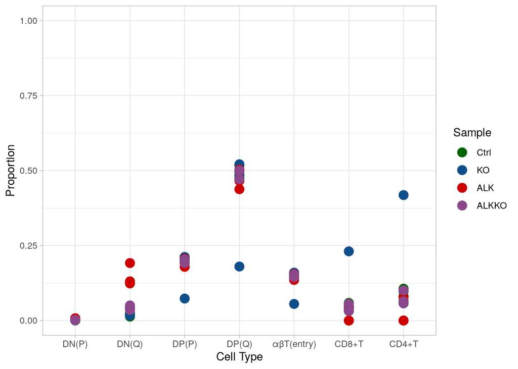

```r
#proportions
result <- deconvolution.real_data$prop.est

#sorting the rows with samples
result.sorted <- rbind(result[7:9,], result[4:6,], result[10:12,], result[1:3,])

result.sorted <- order_result_generic(result.sorted, 1, 29)

#get just the clusters that I need
result.sorted <- result.sorted[, paste0('cluster_', c(8,9,10,11,28,4,3))]

results_summarized <- cbind(result.sorted)
colnames(results_summarized) <- list_pseudotime[1:7]

thymus.result.summarized <- as.data.frame(t(results_summarized[]))
thymus.result.summarized <- cbind(thymus.result.summarized, cluster_name = rownames(thymus.result.summarized))

thymus.prop.summarized.melt <- melt(thymus.result.summarized, id.vars='cluster_name')
thymus.prop.summarized.melt <- cbind(thymus.prop.summarized.melt, type = '', type_normalized = '', stringsAsFactors=FALSE)

thymus.prop.summarized.melt <- within(thymus.prop.summarized.melt, type_normalized[str_sub(variable, 1, 6) == 'Thy_WT'] <- 'Ctrl')
thymus.prop.summarized.melt <- within(thymus.prop.summarized.melt, type_normalized[str_sub(variable, 1, 6) == 'Thy_KO'] <- 'KO')
thymus.prop.summarized.melt <- within(thymus.prop.summarized.melt, type_normalized[str_sub(variable, 1, 15) == 'Tumor_ALKpos_WT'] <- 'ALK')
thymus.prop.summarized.melt <- within(thymus.prop.summarized.melt, type_normalized[str_sub(variable, 1, 13) == 'Thy_ALKpos_KO'] <- 'ALKKO')

thymus.prop.summarized.melt$type_normalized <- factor(thymus.prop.summarized.melt$type_normalized, levels= c('Ctrl', 'KO', 'ALK', 'ALKKO'))
thymus.prop.summarized.melt$cluster_name <- factor(thymus.prop.summarized.melt$cluster_name, levels=  list_pseudotime[1:7])

#all samples/replicas
p <- ggplot(thymus.prop.summarized.melt[thymus.prop.summarized.melt$type_normalized %in% c('Ctrl', 'KO', 'ALK', 'ALKKO') & thymus.prop.summarized.melt$cluster_name %in% list_pseudotime,], aes(x=cluster_name, y=value, color=type_normalized)) +
  geom_point(size=6, shape=20) +
  labs(title=NULL,x="Cell Type", y = "Proportion") + theme_linedraw() +
    theme(axis.text.x = element_text(angle = 45, hjust = 1),
        axis.text=element_text(size=16),
        axis.title=element_text(size=18,face="bold"),
        plot.title = element_text(size = 18, face = "italic"),
        legend.title = element_text(size = 16),
          legend.text = element_text(size = 16)) +
  ylim(0, 1.0)
p +  scale_color_manual(name = "Sample", breaks = c('Ctrl', 'KO', 'ALK', 'ALKKO'), values = c("#006400", "#104E8B", "#CD0000", "#8B4789")) + theme_light()
```

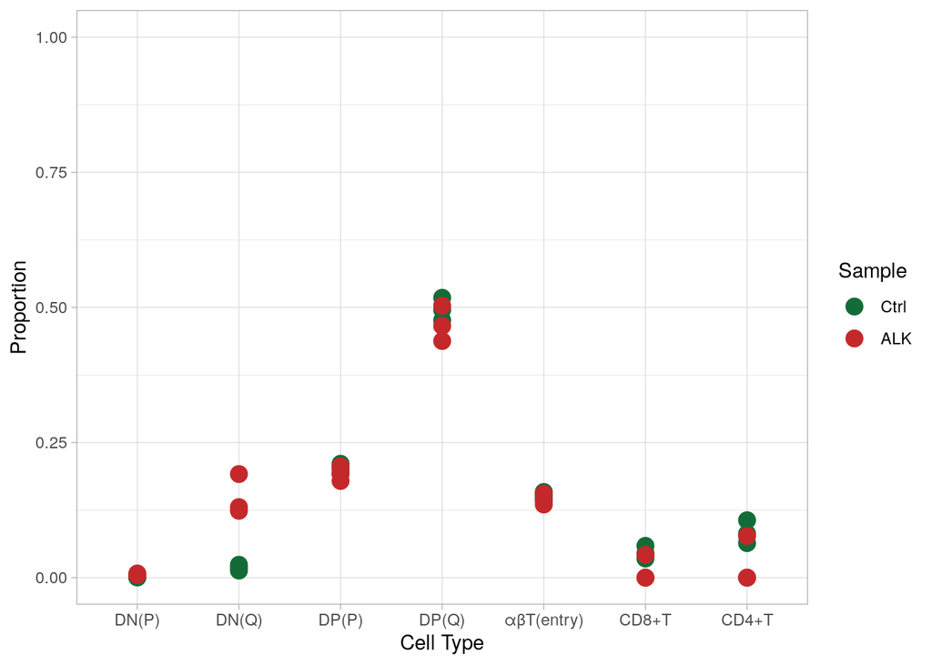

```r
#ALK replicas
p <- ggplot(thymus.prop.summarized.melt[thymus.prop.summarized.melt$type_normalized %in% c('Ctrl', 'ALK') & thymus.prop.summarized.melt$cluster_name %in% list_pseudotime,], aes(x=cluster_name, y=value, color=type_normalized)) +
  geom_point(size=6, shape=20) +
  labs(title=NULL,x="Cell Type", y = "Proportion") + theme_linedraw() +
    theme(axis.text.x = element_text(angle = 45, hjust = 1),
        axis.text=element_text(size=16),
        axis.title=element_text(size=18,face="bold"),
        plot.title = element_text(size = 18, face = "italic"),
        legend.title = element_text(size = 16),
          legend.text = element_text(size = 16)) +
  ylim(0, 1.0)

p +  scale_color_manual(name = "Sample", breaks = c('Ctrl', 'KO', 'ALK', 'ALKKO'), values = c("#136c38", "#1f5a8b", "#c5282a", "#92578a")) + theme_light()
```

Comparison between the actual proportions of the single-cell data and the estimated proportions of the bulk thymus data, specifically with the Ctrl sample.

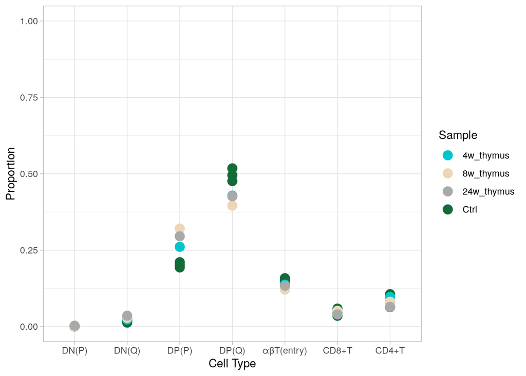

```r
#Calculate the proportion for clusters where 13,16,22 and 23 don't have cells, that means 20 clusters.
real_proportion <- calculate_proportions_4w_8w_24w(eset.sc.thymus.4.sparse.metacluster, 29)
real_proportion.pseudotime <- real_proportion[, c(8,9,10,11,28,4,3)]

real_proportion.pseudotime.rescaled <- NULL
for(counter in 1:nrow(real_proportion.pseudotime)){
  new_row <- real_proportion.pseudotime[counter,]/sum(real_proportion.pseudotime[counter,])
  real_proportion.pseudotime.rescaled <- rbind(real_proportion.pseudotime.rescaled, new_row)
}

colnames(real_proportion.pseudotime.rescaled) <- list_pseudotime

comparison_real_vs_deconvolution <- rbind(results_summarized[1:12,], real_proportion.pseudotime.rescaled)


thymus.proportions.summarized <- as.data.frame(t(comparison_real_vs_deconvolution[]))

thymus.proportions.summarized <- cbind(thymus.proportions.summarized, cluster_name = rownames(thymus.proportions.summarized))


thymus.proportions.summarized.melt <- melt(thymus.proportions.summarized, id.vars='cluster_name')
thymus.proportions.summarized.melt <- cbind(thymus.proportions.summarized.melt, type = '', type_normalized = '', stringsAsFactors=FALSE)

thymus.proportions.summarized.melt$cluster_name <- factor(thymus.proportions.summarized.melt$cluster_name, levels = list_pseudotime)

thymus.proportions.summarized.melt <- within(thymus.proportions.summarized.melt, type_normalized[str_sub(variable, 1, 6) == 'Thy_WT'] <- 'Ctrl')
thymus.proportions.summarized.melt <- within(thymus.proportions.summarized.melt, type_normalized[str_sub(variable, 1, 6) == 'Thy_KO'] <- 'KO')
thymus.proportions.summarized.melt <- within(thymus.proportions.summarized.melt, type_normalized[str_sub(variable, 1, 15) == 'Tumor_ALKpos_WT'] <- 'ALK')
thymus.proportions.summarized.melt <- within(thymus.proportions.summarized.melt, type_normalized[str_sub(variable, 1, 13) == 'Thy_ALKpos_KO'] <- 'ALKKO')
thymus.proportions.summarized.melt <- within(thymus.proportions.summarized.melt, type_normalized[str_sub(variable, 1, 13) == '4w_thymus'] <- '4w_thymus')
thymus.proportions.summarized.melt <- within(thymus.proportions.summarized.melt, type_normalized[str_sub(variable, 1, 13) == '8w_thymus'] <- '8w_thymus')
thymus.proportions.summarized.melt <- within(thymus.proportions.summarized.melt, type_normalized[str_sub(variable, 1, 13) == '24w_thymus'] <- '24w_thymus')

thymus.proportions.summarized.melt$type_normalized <- factor(thymus.proportions.summarized.melt$type_normalized, levels= c('Ctrl', 'KO', 'ALK', 'ALKKO', '4w_thymus', '8w_thymus', '24w_thymus'))

#real proportion vs control
thymus.proportions.deconvolution.summarized.melt <- rbind(thymus.proportions.summarized.melt)

p <- ggplot(thymus.proportions.deconvolution.summarized.melt[thymus.proportions.deconvolution.summarized.melt$type_normalized %in% c('4w_thymus','8w_thymus', '24w_thymus', 'Ctrl') & thymus.proportions.deconvolution.summarized.melt$cluster_name %in% list_pseudotime,], aes(x=cluster_name, y=value, color=type_normalized)) +
  geom_point(size=6, shape=20) +
  labs(title=NULL,x="Cell Type", y = "Proportion") + theme_linedraw() +
    theme(axis.text.x = element_text(angle = 45, hjust = 1),
        axis.text=element_text(size=16),
        legend.title = element_text(size = 16),
          legend.text = element_text(size = 16)) +
  ylim(0, 1.0)

p +  scale_color_manual(name = "Sample", breaks = c('4w_thymus', '8w_thymus', '24w_thymus', 'Ctrl'), values = c("turquoise3", "bisque2", "darkgrey", "#136c38")) + theme_light()
```

Concordance between each replica in the bulk data and the single-cell data in different time points using the marker genes selected in the deconvolution. Each value corresponding to the correlation between the time points and the replicas.

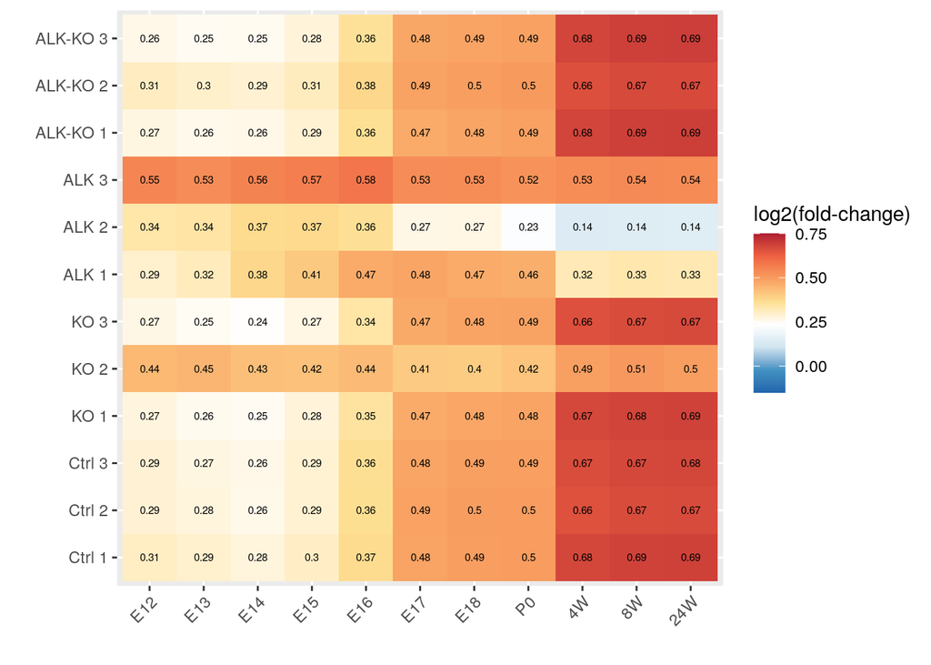

```r
#for each sample"4W"  "8W"  "24W" "E14" "E16" "P0"  "E18" "E12" "E13" "E15" "E17" I have to change the reference
marker.list.plot <- as.character(markers.deconvolution.real_data)

verbose <- FALSE

concordance.all.time.points.df <- NULL
colnames_time_points <- colnames(pseudo.eset.sc.thymus.4.sparse.all$pseudo_eset@assayData$exprs)
for(counter_time_point in 1:length(colnames_time_points)){
  colnames_samples <- colnames(eset.thymus.bulk.sparse@assayData$exprs)
  for(counter in 1:length(colnames_samples)){
    time_point <- colnames_time_points[counter_time_point]
    result <- cor(pseudo.eset.sc.thymus.4.sparse.all$pseudo_eset@assayData$exprs[marker.list.plot,time_point], eset.thymus.bulk.sparse@assayData$exprs[marker.list.plot,counter])

    #show information for each calculation
    if(verbose)
      print(paste0(time_point, '-',colnames_samples[counter], ':', result))

    concordance.all.time.points.df <- rbind(concordance.all.time.points.df, c(time_point,colnames_samples[counter], result))
  }
}

concordance.all.time.points.df <- data.frame(time_point = concordance.all.time.points.df[,1], sample=concordance.all.time.points.df[,2], value = as.numeric(concordance.all.time.points.df[,3]), sample_normalized = '')

age_levels <- c('E12', 'E13', 'E14', 'E15','E16', 'E17', 'E18', 'P0', "4W", "8W", "24W")
sample_levels <- c('Thy_WT_1', 'Thy_WT_2', 'Thy_WT_3',
                   "Thy_KO_1", "Thy_KO_2", "Thy_KO_3",
                   'Tumor_ALKpos_WT_1', 'Tumor_ALKpos_WT_2', 'Tumor_ALKpos_WT_3',
                   "Thy_ALKpos_KO_1", "Thy_ALKpos_KO_2","Thy_ALKpos_KO_3")

sample_levels_normalized <- c('Ctrl 1', 'Ctrl 2', 'Ctrl 3',
                   "KO 1", "KO 2", "KO 3",
                   'ALK 1', 'ALK 2', 'ALK 3',
                   "ALK-KO 1", "ALK-KO 2","ALK-KO 3")

concordance.all.time.points.df$sample_normalized <- factor(concordance.all.time.points.df$sample_normalized, levels = sample_levels_normalized)

concordance.all.time.points.df <- within(concordance.all.time.points.df, sample_normalized[sample == 'Thy_WT_1'] <- 'Ctrl 1')
concordance.all.time.points.df <- within(concordance.all.time.points.df, sample_normalized[sample == 'Thy_WT_2'] <- 'Ctrl 2')
concordance.all.time.points.df <- within(concordance.all.time.points.df, sample_normalized[sample == 'Thy_WT_3'] <- 'Ctrl 3')

concordance.all.time.points.df <- within(concordance.all.time.points.df, sample_normalized[sample == 'Thy_KO_1'] <- 'KO 1')
concordance.all.time.points.df <- within(concordance.all.time.points.df, sample_normalized[sample == 'Thy_KO_2'] <- 'KO 2')
concordance.all.time.points.df <- within(concordance.all.time.points.df, sample_normalized[sample == 'Thy_KO_3'] <- 'KO 3')

concordance.all.time.points.df <- within(concordance.all.time.points.df, sample_normalized[sample == 'Tumor_ALKpos_WT_1'] <- 'ALK 1')
concordance.all.time.points.df <- within(concordance.all.time.points.df, sample_normalized[sample == 'Tumor_ALKpos_WT_2'] <- 'ALK 2')
concordance.all.time.points.df <- within(concordance.all.time.points.df, sample_normalized[sample == 'Tumor_ALKpos_WT_3'] <- 'ALK 3')

concordance.all.time.points.df <- within(concordance.all.time.points.df, sample_normalized[sample == 'Thy_ALKpos_KO_1'] <- 'ALK-KO 1')
concordance.all.time.points.df <- within(concordance.all.time.points.df, sample_normalized[sample == 'Thy_ALKpos_KO_2'] <- 'ALK-KO 2')
concordance.all.time.points.df <- within(concordance.all.time.points.df, sample_normalized[sample == 'Thy_ALKpos_KO_3'] <- 'ALK-KO 3')


concordance.all.time.points.df$time_point <- factor(concordance.all.time.points.df$time_point, levels= age_levels)
concordance.all.time.points.df$sample <- factor(concordance.all.time.points.df$sample, levels = sample_levels)

#plot of concordance for each time point and replica
p <- ggplot(concordance.all.time.points.df,  aes(time_point, sample_normalized, fill= value)) +
  scale_fill_gradientn(colours = c("#2166AC", "#4393C3", "#D1E5F0", "#ffffff", "#fddf92", "#f89f61", "#ef6242", "#af1d31"), na.value = 'gray88', limits=c(-0.15, .75)) +
  geom_tile() +
  theme(axis.text.x = element_text(angle = 45, hjust = 1)) +
  labs(title=NULL,x="", y = "", fill = "log2(fold-change)")
p + geom_text(aes(label=round(value,2)), size=2)
```

# Bulk RNA-seq simulation and differential expression analysis

Due to the heterogeneity of the ALK tumor sample, we constructed a simulation of bulk data samples based on the sc-RNA-seq data applying the proportions estimated by the deconvolution for each replica and only taking into account the 7 cell types used in the deconvolution for ages 4, 8 and 24 weeks. We wanted to see if there were highly expressed genes in the bulk ALK tumor sample that can not be well explained by the simulated mixture, therefore these shouldn’t be marker genes.

```r
#I got for each cell type the actual summary for each gene. I have some doubts about the counting coherence with the original bulk data
pseudotime.celltypes <- c(paste0('cluster_', c(8,9,10,11,28,4,3)))

#filtered bulk data
bulk.data.count <- eset.thymus.bulk.sparse@assayData$exprs
bulk.data.count <- bulk.data.count[rowSums(bulk.data.count[,]) >0,]

#filtered single cell data
sc.data.count <- seurat_object.4w_8w_24w@assays$RNA@counts
sc.data.count <- sc.data.count[rowSums(sc.data.count[,]) >0,]

#calculate the genes shared between the bulk and single cell data.
shared.genes.bulk.single_cell <- Reduce(intersect, list(rownames(sc.data.count), rownames(bulk.data.count)))
print(paste0("Shared between the bulk and single cell data: ",length(shared.genes.bulk.single_cell)))
```

```
## [1] "Shared between the bulk and single cell data: 15283"
```

```r
#filtering the single cell data with the shared genes and only for the cell types of interest (7 T-Cell)
celltype.counting.pseudotime.all <- sc.data.count[shared.genes.bulk.single_cell, seurat_object.4w_8w_24w$cluster_normalized %in% pseudotime.celltypes]

#Check the relative percentage of the 7 T-Cell types with respecto to the whole sc-RNA-seq dataset
pseudotime.sum <- sum(celltype.counting.pseudotime.all)
all.sum <- sum(sc.data.count[shared.genes.bulk.single_cell,])
percentage <- pseudotime.sum/all.sum
#0.9336861 (3 Time points)
print(paste0("Relative percentage: ", round(percentage,4)*100))
```

```
## [1] "Relative percentage: 93.37"
```

```r
#Calculate the summarized object based on the single cell data
pseudotime.summary.by.celltype <- create_summary_single_cell(pseudotime.celltypes, shared.genes.bulk.single_cell, seurat_object.4w_8w_24w, sc.data.count)

#I got the proportions from the deconvolution
print("Proportions calculated for the deconvolution: ")
```

```
## [1] "Proportions calculated for the deconvolution: "
```

```r
deconvolution.real_data$prop.est
```

```
##                      cluster_8  cluster_9 cluster_10 cluster_11 cluster_28
## Thy_ALKpos_KO_1   0.0018051398 0.04607353 0.20247203  0.4975508 0.15254025
## Thy_ALKpos_KO_2   0.0013836954 0.03521908 0.19179073  0.4710424 0.14438704
## Thy_ALKpos_KO_3   0.0019639378 0.05032387 0.20365206  0.5004072 0.15343460
## Thy_KO_1          0.0006587638 0.01699501 0.19731632  0.4852289 0.14869720
## Thy_KO_2          0.0016464474 0.04065966 0.07331268  0.1800682 0.05537863
## Thy_KO_3          0.0006773303 0.01745625 0.21208672  0.5210957 0.15964953
## Thy_WT_1          0.0007158775 0.01839062 0.19366158  0.4761377 0.14594255
## Thy_WT_2          0.0005110088 0.01310573 0.21074267  0.5178189 0.15854992
## Thy_WT_3          0.0009266449 0.02385093 0.20156446  0.4955295 0.15187073
## Tumor_ALKpos_WT_1 0.0077332317 0.19170722 0.19157444  0.4657884 0.14319675
## Tumor_ALKpos_WT_2 0.0052343420 0.13053695 0.20607800  0.5031467 0.15500402
## Tumor_ALKpos_WT_3 0.0049743574 0.12368282 0.17890252  0.4377909 0.13537832
##                    cluster_3  cluster_4
## Thy_ALKpos_KO_1   0.06410372 0.03545451
## Thy_ALKpos_KO_2   0.10055374 0.05562328
## Thy_ALKpos_KO_3   0.05805713 0.03216119
## Thy_KO_1          0.09730023 0.05380363
## Thy_KO_2          0.41822173 0.23071261
## Thy_KO_3          0.05728741 0.03174710
## Thy_WT_1          0.10628566 0.05886603
## Thy_WT_2          0.06388585 0.03538593
## Thy_WT_3          0.08129509 0.04496268
## Tumor_ALKpos_WT_1 0.00000000 0.00000000
## Tumor_ALKpos_WT_2 0.00000000 0.00000000
## Tumor_ALKpos_WT_3 0.07703257 0.04223851
```

```r
#Applying proportions to the complete set of replicas and samples in the original bulk thymus data.
bulk.simulated.thymus.pseudotime <- apply_proportions_complete_single_cell_dataset(bulk.data.count, deconvolution.real_data, pseudotime.summary.by.celltype)

#getting the final bulk data. I build the bulk data for the analysis.
print("Bulk data simulated:")
```

```
## [1] "Bulk data simulated:"
```

```r
head(bulk.simulated.thymus.pseudotime)
```

```
##               simu_Thy_ALKpos_KO_1 simu_Thy_ALKpos_KO_2 simu_Thy_ALKpos_KO_3
## 0610005C13Rik                30942                30367                30987
## 0610009B22Rik               468712               457055               471500
## 0610010F05Rik               220598               214186               222279
## 0610012G03Rik              2124255              2150898              2120403
## 0610030E20Rik              1549121              1555960              1546783
## 0610038B21Rik                27687                27512                27782
##               simu_Thy_KO_1 simu_Thy_KO_2 simu_Thy_KO_3 simu_Thy_WT_1
## 0610005C13Rik         30823         23299         31687         30594
## 0610009B22Rik        451244        390222        460158        449773
## 0610010F05Rik        209779        184059        213898        209235
## 0610012G03Rik       2143738       2408876       2111518       2151246
## 0610030E20Rik       1564450       1569567       1562144       1564140
## 0610038B21Rik         26994         28796         26863         27064
##               simu_Thy_WT_2 simu_Thy_WT_3 simu_Tumor_ALKpos_WT_1
## 0610005C13Rik         31631         31031                  29274
## 0610009B22Rik        457224        457142                 534807
## 0610010F05Rik        212126        213145                 264989
## 0610012G03Rik       2115755       2132542                2108952
## 0610030E20Rik       1564517       1560420                1476901
## 0610038B21Rik         26763         27128                  31500
##               simu_Tumor_ALKpos_WT_2 simu_Tumor_ALKpos_WT_3
## 0610005C13Rik                  30569                  29046
## 0610009B22Rik                 512811                 493416
## 0610010F05Rik                 249038                 239588
## 0610012G03Rik                2093661                2154405
## 0610030E20Rik                1505886                1513408
## 0610038B21Rik                  29807                  29902
```

Downloading of the library: [GTFtools](https://www.biorxiv.org/content/10.1101/263517v1.full) from [GTFtools version:0.6.9](http://www.genemine.org/gtftools.php) and the corresponding gencode annotation file to calculate the size of the genes. The pre-requisites for the gene size calculation are: Linux system (Ubuntu or Debian based), python 2 and the GTFtools installed. We need the gene size in order to calculate the TPM normalization for the bulk data.

```bash
#Install the tool version:0.6.9  -> http://www.genemine.org/gtftools.php
mkdir temporal
cd temporal
wget http://www.genemine.org/codes/GTFtools_0.6.9.zip
unzip GTFtools_0.6.9.zip

#download the gencode annotation file that coincides with the alignment that we use for creating the counting files. Use the webpage: https://www.gencodegenes.org/mouse/release_M25.html
wget ftp://ftp.ebi.ac.uk/pub/databases/gencode/Gencode_mouse/release_M24/gencode.vM24.annotation.gtf.gz
gunzip gencode.vM24.annotation.gtf.gz

#I got 55349
python2 GTFtools_0.6.9/gtftools.py -l gene_length.gencode.vM24.annotation.bed gencode.vM24.annotation.gtf

#genes and gene.id: I got 55385
awk '{print $9$10 $15$16}' gencode.vM24.annotation.gtf > gene.id.name.txt
uniq gene.id.name.txt > gene.id.name.unique.txt
grep -nr "gene_name" gene.id.name.unique.txt > gene.id.name.unique.2.txt
```

Generation of the summary with different kind of size calculation for each gene.

```r
path <-  paste0(getwd(), '/', 'temporal/')
gene.file.name <- 'gene.id.name.unique.2.txt'
gene_length.file.name <- 'gene_length.gencode.vM24.annotation.bed'

##########################gene.id vs gene.name
gene.file <- read.csv(paste0(path, gene.file.name), header = FALSE, sep = ";")
gene.file <- gene.file[,1:2]

#get just the gene.id
gene.ids.list <- lapply(gene.file[,1], function (x) substr(x, unlist(str_locate(x, 'ENSMUS'))[1], nchar(as.character(x))))

#I got 50600 unique gene.id and 50508 unique gene names
gene.file.df <- data.frame(gene= unlist(gene.ids.list),
                           gene.name = str_remove_all(gene.file[,2], 'gene_name'))


##########################genes' length
gene_length.file.df <- read.csv(paste0(path, gene_length.file.name), header = TRUE, sep = "\t")

#################JOIN of the length and the names
genes.plus.length <- gene_length.file.df %>% inner_join(gene.file.df)
print("")
```

```
## [1] ""
```

```r
print(paste0("Genes with length and name: ", length(genes.plus.length$gene.name)))
```

```
## [1] "Genes with length and name: 55348"
```

```r
print(paste0("Unique genes: ", unique(length(genes.plus.length$gene.name))))
```

```
## [1] "Unique genes: 55348"
```

Normalization of the bulk data using [TPM strategy](https://www.ncbi.nlm.nih.gov/pmc/articles/PMC6923842/).

```r
#calculate the shared genes between bulk data and df with genes' lenght
bulk.data.count <- eset.thymus.bulk.sparse@assayData$exprs

#46816 genes from 50532 in the bulk data
shared.genes <-  Reduce(intersect, list(genes.plus.length$gene.name, rownames(bulk.data.count)))
length(unique(shared.genes))
```

```
## [1] 49870
```

```r
#new bulk data with the genes that have lenght information
bulk.data.count.filtered <- bulk.data.count[rownames(bulk.data.count) %in% shared.genes,]
genes.plus.length.filtered <- genes.plus.length[genes.plus.length$gene.name %in% shared.genes, ]

length.genes.list <- genes.plus.length.filtered$merged
names(length.genes.list) <- genes.plus.length.filtered$gene.name

#I order by the shared genes vector and calculate the tpm count
bulk.data.count.TPM <- r_tpm(bulk.data.count.filtered[shared.genes,], length.genes.list[shared.genes])
```

We choose the top 10% of the most highly expressed genes in the original bulk data using TPM normalization

```r
#I added the marker genes at the begining
selected.genes.TPM <- markers.deconvolution.real_data
for(counter in 1:ncol(bulk.data.count.TPM) ){
  sample <- bulk.data.count.TPM[,counter]
  sample <- sort(sample)
  size <- as.integer(length(sample)*.10)
  top.10.percentage <- tail(sample, size)
  selected.genes.TPM <- c(selected.genes.TPM, names(top.10.percentage))
  selected.genes.TPM <- unique(selected.genes.TPM)
}

#7550 without marker genes
print(paste0('Genes in the Top 10% + marker genes: ', length(selected.genes.TPM)))
```

```
## [1] "Genes in the Top 10% + marker genes: 7558"
```

Differential expression analysis using DESeq2 between the set of replicas for each sample and the corresponding replicas in the simulation

```r
#Create the bulk dataset for each comparison (all simulated samples vs specific sample)
bulk.simulated.thymus.pseudotime.plus.actual.tumor.Thy_WT <- cbind(bulk.simulated.thymus.pseudotime, bulk.data.count[rownames(bulk.simulated.thymus.pseudotime), c(7,8,9)])
bulk.simulated.thymus.pseudotime.plus.actual.tumor.Thy_KO <- cbind(bulk.simulated.thymus.pseudotime, bulk.data.count[rownames(bulk.simulated.thymus.pseudotime), c(4,5,6)])
bulk.simulated.thymus.pseudotime.plus.actual.tumor.Thy_ALKpos_WT <- cbind(bulk.simulated.thymus.pseudotime, bulk.data.count[rownames(bulk.simulated.thymus.pseudotime), c(10,11,12)])
bulk.simulated.thymus.pseudotime.plus.actual.tumor.Thy_ALKpos_KO <- cbind(bulk.simulated.thymus.pseudotime, bulk.data.count[rownames(bulk.simulated.thymus.pseudotime), c(1,2,3)])

#calculate each differential analyisis in each experiment:
RES.thymus.lfc.Thy_WT <- create_differential_expression_set('Thy_WT', selected.genes.TPM, bulk.simulated.thymus.pseudotime.plus.actual.tumor.Thy_WT)
RES.thymus.lfc.Thy_KO <- create_differential_expression_set('Thy_KO', selected.genes.TPM, bulk.simulated.thymus.pseudotime.plus.actual.tumor.Thy_KO)
RES.thymus.lfc.Thy_ALKpos_WT <- create_differential_expression_set('Thy_ALKpos_WT', selected.genes.TPM, bulk.simulated.thymus.pseudotime.plus.actual.tumor.Thy_ALKpos_WT)
RES.thymus.lfc.Thy_ALKpos_KO <- create_differential_expression_set('Thy_ALKpos_KO', selected.genes.TPM, bulk.simulated.thymus.pseudotime.plus.actual.tumor.Thy_ALKpos_KO)
```

Heatmap with the log2(fold-change) values of the real vs simulated samples for the marker genes selected in the deconvolution.

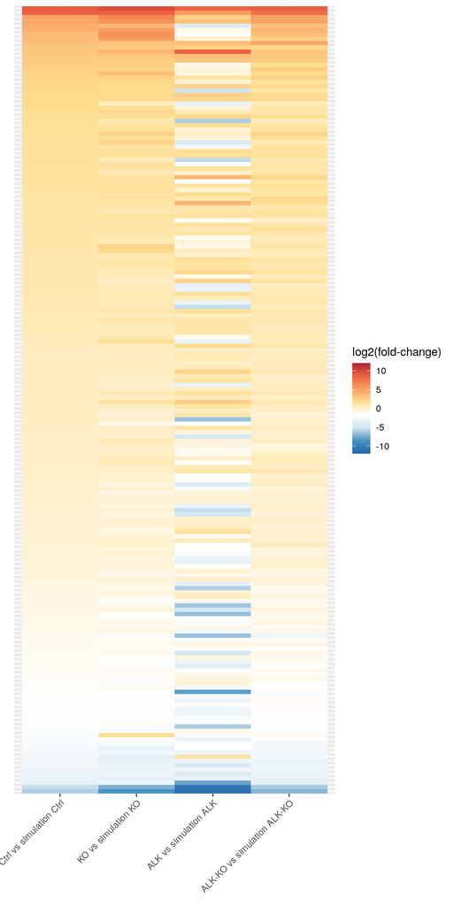

```r
shared.genes.foldchange <- Reduce(intersect, list(rownames(RES.thymus.lfc.Thy_WT$treatment_simu_Thy_WT_vs_Thy_WT[,]),
                                                  rownames(RES.thymus.lfc.Thy_KO$treatment_simu_Thy_KO_vs_Thy_KO[,]),
                                                  rownames(RES.thymus.lfc.Thy_ALKpos_WT$treatment_simu_Thy_ALKpos_WT_vs_Thy_ALKpos_WT[,]),
                                                  rownames(RES.thymus.lfc.Thy_ALKpos_KO$treatment_simu_Thy_ALKpos_KO_vs_Thy_ALKpos_KO[,])))

treatment_simu_Thy_WT_vs_Thy_WT <- RES.thymus.lfc.Thy_WT$treatment_simu_Thy_WT_vs_Thy_WT[shared.genes.foldchange, ]
treatment_simu_Thy_ALKpos_WT_vs_Thy_ALKpos_WT <- RES.thymus.lfc.Thy_ALKpos_WT$treatment_simu_Thy_ALKpos_WT_vs_Thy_ALKpos_WT[shared.genes.foldchange, ]
treatment_simu_Thy_KO_vs_Thy_KO <- RES.thymus.lfc.Thy_KO$treatment_simu_Thy_KO_vs_Thy_KO[shared.genes.foldchange, ]
treatment_simu_Thy_ALKpos_KO_vs_Thy_ALKpos_KO <- RES.thymus.lfc.Thy_ALKpos_KO$treatment_simu_Thy_ALKpos_KO_vs_Thy_ALKpos_KO[shared.genes.foldchange, ]

#Creation of the dataframe with simulation vs the actual sample (Original differential expression analyisis)
dataset.heatmap.0 <- data.frame(treatment_simu_Thy_WT_vs_Thy_WT = treatment_simu_Thy_WT_vs_Thy_WT$log2FoldChange,
                                treatment_simu_Thy_ALKpos_WT_vs_Thy_ALKpos_WT = treatment_simu_Thy_ALKpos_WT_vs_Thy_ALKpos_WT$log2FoldChange,
                                treatment_simu_Thy_KO_vs_Thy_KO = treatment_simu_Thy_KO_vs_Thy_KO$log2FoldChange,
                                treatment_simu_Thy_ALKpos_KO_vs_Thy_ALKpos_KO = treatment_simu_Thy_ALKpos_KO_vs_Thy_ALKpos_KO$log2FoldChange,
                                gene = shared.genes.foldchange)

#Creation of the dataframe with the actual sample vs simulation (multiplying -1)
dataset.heatmap.1 <- data.frame('Thy_WT_vs_simu_Thy_WT' = treatment_simu_Thy_WT_vs_Thy_WT$log2FoldChange * -1,
                                'Thy_ALKpos_WT_vs_simul_Thy_ALKpos_WT' = treatment_simu_Thy_ALKpos_WT_vs_Thy_ALKpos_WT$log2FoldChange * -1,
                                'Thy_KO_vs_simu_Thy_KO' = treatment_simu_Thy_KO_vs_Thy_KO$log2FoldChange * -1,
                                'Thy_ALKpos_KO_vs_simu_Thy_ALKpos_KO' = treatment_simu_Thy_ALKpos_KO_vs_Thy_ALKpos_KO$log2FoldChange * -1,
                                gene = shared.genes.foldchange)

#sorting for foldchange in the thymus WT
dataset.heatmap.1 <- dataset.heatmap.1[ order(dataset.heatmap.1$Thy_WT_vs_simu_Thy_WT), ]

data <- melt(dataset.heatmap.1[,], id.vars='gene')
data$value <- as.numeric(data$value)
colnames(data) <- c('genes', 'comparison', 'value')

#order
data$gene <- factor(data$genes, levels = dataset.heatmap.1$gene)

data <- data.frame(data, comparison_normalized = '')
data$comparison_normalized <- factor(data$comparison_normalized, levels = c('Ctrl vs simulation Ctrl',
                                                      'KO vs simulation KO',
                                                      'ALK vs simulation ALK',
                                                      'ALK-KO vs simulation ALK-KO'))

data$comparison <- factor(data$comparison, levels = c('Thy_WT_vs_simu_Thy_WT',
                                                      'Thy_KO_vs_simu_Thy_KO',
                                                      'Thy_ALKpos_WT_vs_simul_Thy_ALKpos_WT',
                                                      'Thy_ALKpos_KO_vs_simu_Thy_ALKpos_KO'))

data <- within(data, comparison_normalized[comparison == 'Thy_WT_vs_simu_Thy_WT'] <- 'Ctrl vs simulation Ctrl')
data <- within(data, comparison_normalized[comparison == 'Thy_KO_vs_simu_Thy_KO'] <- 'KO vs simulation KO')
data <- within(data, comparison_normalized[comparison == 'Thy_ALKpos_WT_vs_simul_Thy_ALKpos_WT'] <- 'ALK vs simulation ALK')
data <- within(data, comparison_normalized[comparison == 'Thy_ALKpos_KO_vs_simu_Thy_ALKpos_KO'] <- 'ALK-KO vs simulation ALK-KO')

#plot of marker genes
ggplot(data[data$gene %in% markers.deconvolution.real_data,], aes(x=comparison_normalized, y=gene , fill= value)) +
  geom_tile() +
theme(axis.text.x = element_text(angle = 45, hjust = 1)
      ,axis.text.y = element_blank()
      ,axis.ticks.y = element_blank()
      ) +
   scale_fill_gradientn(colours = c("#2166AC", "#4393C3", "#D1E5F0", "#ffffff", "#fddf92", "#f89f61", "#ef6242", "#af1d31"), na.value = 'gray88', limits=c(-12, 12)) +
  labs(y= element_blank(), x = element_blank(), fill = "log2(fold-change)")
```

List of both up and down regulated genes, having as a reference the tumor sample analysis. We use a limit in log2(fold-change) of (3, -3) considering the others analysis with values in (-1, 1)

```r
threshold.log2foldchange.up <- 3
threshold.log2foldchange.down <- -3

#We filter the marker genes
upregulated.tumor <- dataset.heatmap.1[ !(dataset.heatmap.1$gene %in% markers.deconvolution.real_data) &
                                        ((dataset.heatmap.1$Thy_WT_vs_simu_Thy_WT < dataset.heatmap.1$Thy_ALKpos_WT_vs_simul_Thy_ALKpos_WT &
                                          dataset.heatmap.1$Thy_WT_vs_simu_Thy_WT < 1 &
                                          dataset.heatmap.1$Thy_WT_vs_simu_Thy_WT > -1 &
                                          dataset.heatmap.1$Thy_ALKpos_WT_vs_simul_Thy_ALKpos_WT > threshold.log2foldchange.up) |

                                         (dataset.heatmap.1$Thy_KO_vs_simu_Thy_KO < dataset.heatmap.1$Thy_ALKpos_WT_vs_simul_Thy_ALKpos_WT &
                                          dataset.heatmap.1$Thy_KO_vs_simu_Thy_KO < 1 &
                                          dataset.heatmap.1$Thy_KO_vs_simu_Thy_KO > -1 &
                                          dataset.heatmap.1$Thy_ALKpos_WT_vs_simul_Thy_ALKpos_WT > threshold.log2foldchange.up) |

                                         (dataset.heatmap.1$Thy_ALKpos_KO_vs_simu_Thy_ALKpos_KO < dataset.heatmap.1$Thy_ALKpos_WT_vs_simul_Thy_ALKpos_WT &
                                          dataset.heatmap.1$Thy_ALKpos_KO_vs_simu_Thy_ALKpos_KO < 1 &
                                          dataset.heatmap.1$Thy_ALKpos_KO_vs_simu_Thy_ALKpos_KO > -1 &
                                          dataset.heatmap.1$Thy_ALKpos_WT_vs_simul_Thy_ALKpos_WT > threshold.log2foldchange.up)), ]

print(paste0("Up-regulated genes: ", nrow(upregulated.tumor)))
```

```
## [1] "Up-regulated genes: 58"
```

```r
#We filter the marker genes
downregulated.tumor <- dataset.heatmap.1[!(dataset.heatmap.1$gene %in% markers.deconvolution.real_data) &
                                          ((dataset.heatmap.1$Thy_WT_vs_simu_Thy_WT > -1 &
                                            dataset.heatmap.1$Thy_WT_vs_simu_Thy_WT < 1 &
                                            dataset.heatmap.1$Thy_ALKpos_WT_vs_simul_Thy_ALKpos_WT < threshold.log2foldchange.down) |

                                           (dataset.heatmap.1$Thy_KO_vs_simu_Thy_KO > -1 &
                                            dataset.heatmap.1$Thy_KO_vs_simu_Thy_KO < 1 &
                                            dataset.heatmap.1$Thy_ALKpos_WT_vs_simul_Thy_ALKpos_WT < threshold.log2foldchange.down) |

                                           (dataset.heatmap.1$Thy_ALKpos_KO_vs_simu_Thy_ALKpos_KO > -1 &
                                            dataset.heatmap.1$Thy_ALKpos_KO_vs_simu_Thy_ALKpos_KO < 1 &
                                            dataset.heatmap.1$Thy_ALKpos_WT_vs_simul_Thy_ALKpos_WT < threshold.log2foldchange.down)), ]


print(paste0("Down-regulated genes: ", nrow(downregulated.tumor)))
```

```
## [1] "Down-regulated genes: 40"
```

Given the fact that the markers genes can change in about 5% because of the boosting sampling process in the deconvolution, the proportion estimation for each replica could also slightly change generating some variations in the simulated bulk data. We tested different executions and we found that in the worst case the variation of the up-regulated and down-regulated genes is up to 20% with the static threshold.log2foldchange.up of (-3, 3). The rest of the genes, generally could be found by decreasing the range of the query: threshold.log2foldchange = [-2.5, 2.5] for instance.

```r
print(paste0("Current marker genes: ", length(markers.deconvolution.real_data)))
```

```
## [1] "Current marker genes: 182"
```

```r
#Data in the publication
marker.genes.tumor.check <- c('H19',    'Igfbp4',   'Notch1',   'Tyrobp',   'Mki67',    'Top2a',    'Adgrg5',   'Spns2',    'Bst1', 'Kit',  'Gimap4',   'Galnt6',   'Notch3',   'Kif11',    'Fam102a',  'Ccna2',    'Bub1b',    'Racgap1',  'Plekha7',  'S1pr1',    'Tpx2', 'Acvrl1',   'Vim',  'Aurkb',    'Tacc3',    'Cdk1', 'Nusap1',   'Kif15',    'Cenpf',    'Tesc', 'Rrm2', 'Cdca3',    'H2-K1',    'Pbk',  'Prc1', 'Dntt', 'Evl',  'Cenpe',    'Xrcc6',    'Chd3', 'Cdk6', 'Il7r', 'Ccnb2',    'Rcsd1',    'Hmmr', 'Cdc20',    'Tshz2',    'Tifa', 'Actb', 'Atp8b4',   'Lfng', 'Mpzl2',    'Cdca8',    'Esco2',    'Ube2c',    'Birc5',    'Spc25',    'Ccr7', 'Zbtb7b',   'Cd2',  'Asf1b',    'Tyms', 'Tcf12',    'Myb',  'Fbxo5',    'Mxd3', 'Ogt',  'Itgb7',    'Samhd1',   'Hdac4',    'Ccnb1',    'Endou',    'Gprin3',   'Rplp1',    'Ifitm1',   'Hhex', 'Arpp21',   'Spc24',    'Rmnd5a',   'Ctsw', 'Ctsl', 'Pfn1', 'Il2ra',    'Itgae',    'Paqr5',    'Trp53inp1',    'Tmsb4x',   'Tnfrsf4',  'Tuba1b',   'Hes1', 'Dck',  'Pld4', 'Epcam',    'Cyb5a',    'Tmem121',  'Satb1',    'Zeb2', 'Ccl5', 'Aqp11',    'Cdkn1a',   'Klrd1',    '1500009L16Rik',    'Cd27', 'Nkg7', 'Inpp4b',   'Rpl32',    'Adamts17', 'Ets2', 'Klf13',    'Cd53', 'Themis',   'Klk8', 'Bach2',    'Ldhb', 'Tox',  'Itm2a',    'Shisa5',   'Gria3',    'Tespa1',   'Hmgb2',    'Mxd4', 'Bcl2', 'Cd28', 'Smad7',    'Prss57',   'Actn2',    'Ctla2a',   'Mier1',    'Gtf2h4',   'Cd8a', 'Arl5c',    'Ifi27l2a', 'Ikzf2',    'Izumo1r',  'Cd7',  'Gimap3',   'Ckb',  'Cd4',  'Ypel3',    'Smim5',    'Ssbp2',    'Plac8',    'Cks2', 'Ccnd2',    'Bpifc',    'Klf2', 'Nsg2', 'Tmsb10',   'Arap2',    'Cd226',    'Rab44',    'Pacsin1',  'Mpo',  'Slfn1',    'Sstr2',    'Ms4a4b',   'Dnajc15',  'Socs1',    'Ccr9', 'Nebl', 'Scin', 'Cpa3', 'Chrna9',   'Cd8b1',    'Fgf3', 'Myl10',    'Cd40lg',   'Slc7a11',  'Cd5',  'Khdc1a',   'Tctex1d1', 'Actg1',    'Dgkeos',   'Ifitm2',   'Gm5111')

upregulated.tumor.check <- c('Alx4',    'Aqp9', 'Tbx19',    'Lhfpl3',   'Bricd5',   'Fbp1', 'Acox2',    'Tmem150cos',   'Wdr25',    'Hopx', 'Sytl2',    'Amigo2',   'Ceacam1',  'Atp1a3',   'Fam174b',  'Gpx7', 'Elfn2',    'Bmp7', 'Plod2',    'Rgs16',    'Nrarp',    'Rdh10',    'Lonrf1',   'Ano10',    'Etv5', 'Zdhhc2',   'Esm1', 'Col9a3',   'Art2b',    'Mxra7',    'Col27a1',  'Dpp4', 'Cacng4',   'Apbb2',    'Farp2',    'Qsox2',    'Sh2d3c',   'Tmtc4',    'Tnfrsf8',  'Mtmr9',    'Rnf144a',  'Nsg1', 'Tfrc', 'Dtx1', 'Pced1b',   'Camk1g',   'Capg', 'Nwd1', 'Slc22a17')

downregulated.tumor.check <- c('BB031773',  'Fabp3',    'Slc6a19',  'Cd6',  'Lsp1', 'Cd69', 'Pglyrp1',  'Gbp8', 'BC035044', 'Rasgrp1',  'Clec2d',   'Itga4',    'Art1', 'Nr4a1',    'Pth',  'Traf1',    'Il21r',    'Gpr183',   'Eci1', 'Pgam2',    'S1pr4',    'Wdr78',    'Pdcd1',    'Rab19',    'Tdrd5',    'Slfn2',    'AW112010', 'Ifit1bl1', 'Klf4', 'Fbxo27',   'Tbxa2r',   'Dhrs3',    'Apoa2',    'Rasl11b',  'Tec',  'Rrad', 'Gpr162',   'Bin1', 'Isg15')


#checking markers genes
shared_marker.genes.check <- Reduce(intersect, list(marker.genes.tumor.check, markers.deconvolution.real_data))
print(paste0("Shared marker genes: ", length(shared_marker.genes.check), " -> ", round((length(shared_marker.genes.check)/length(marker.genes.tumor.check)), 2) , "%"))
```

```
## [1] "Shared marker genes: 171 -> 0.98%"
```

```r
#checking up-regulated genes
shared_upregulated.check <- Reduce(intersect, list(upregulated.tumor$gene, upregulated.tumor.check))
print(paste0("Shared genes up-regulation: ", length(shared_upregulated.check), " -> ", round((length(shared_upregulated.check)/length(upregulated.tumor.check)), 2) , "%"))
```

```
## [1] "Shared genes up-regulation: 38 -> 0.78%"
```

```r
#checking down-regulated genes
shared_downregulated.check <- Reduce(intersect, list(downregulated.tumor$gene, downregulated.tumor.check))
print(paste0("Shared genes down-regulation: ", length(shared_downregulated.check), " -> ", round((length(shared_downregulated.check)/length(downregulated.tumor.check)), 2) , "%"))
```

```
## [1] "Shared genes down-regulation: 33 -> 0.85%"
```